# 重庆二手房简析

Yaha

2018年9月13日

### 背景说明

小王在重庆工作十年，打算要二胎，想要买个大点的房子，不想太折腾，希望了解一下重庆的二手房信息。包括重庆二手房供应量，价格区间以及价格走势。 小王一家现住渝中，夫妻上班都在江北或渝北。**房子首选北区，面积在110-150平，总价在150-200万**，三房或四房均可。交通，商业都方便点的，最好有好的学校，装修差或者老房子的话预算要减少10万，会自己重装。

### 1 获取数据

爬虫从链家抓数据,代码参考 lianjia-spider  
根据提示准备好python 3* 环境，运行命令爬取数据保存为csv格式。 这里爬取重庆主城9区（江津换北碚?）20180910的数据。

- 小区房价数据存储目录为 data/xiaoqu/city/date
- 二手房房价数据存储目录为 data/ershou/city/date
- 出租房房价数据存储目录为 data/zufang/city/date
- 新房房价数据存储目录为 data/loupan/city/date

## 2 数据处理和加载

需要将csv数据加载进数据库，这里我选**postgres**, 比mysql要好用得多。  
各类数据库都有相应的utility/命令/工具快速加载csv平文件，比如pgfutter之于Postgres, sqlldr之于Oracle, copy之于Vertica，google一下就知道更多了。  
我这里使用R读取文件夹下的csv然后加载进数据库。此方法效率并不高，但数据量小无所谓。  
核心R代码：

```r
library(RJDBC)
xiaoqufiles = list.files(xiaoqupath)
n = length(xiaoqufiles)
df = data.frame()
for (i in 1:n) {
    new.data = read.csv(xiaoqufiles[i], header = FALSE, sep = ",", stringsAsFactors = FALSE,
        fileEncoding = "GBK")
    df = rbind(df, new.data)
}
dbWriteTable(pconn, value = df, name = "ershou", overwrite = TRUE)
```

以上方法的前提是csv是标准的结构化数据。但网页抓取来的数据，可能不规范，比如在ershou数据中，有描述字段内容包含逗号。比如 *“同心家园正规3房,住家安静,视野开阔”* 本应该是一个字段，但在读取csv时会把它视为三个字段，这样加载进数据库时就会出错。解决办法可以是：

1. 抓取数据时分隔符不用逗号，而用正常数据中不会出现的特殊的字符，比如ASCII中不可见字符，或可见字符中 ^, 或者^^这样的。
2. 抓取数据时除了分隔符，还要用包围符号(enclosed by)，常见的当然是双引号。
3. 加载进数据库前用正则表达式匹配出含分隔符的字段，保证数据是结构化的再加载进去。
4. 直接将整行数据当作一个字段加载进数据库，后续再用sql或者procedure编辑方式处理分隔各个字段。  
   比如以下数据在postgres 里提取各个字段，用到split_part(), substring(), strpos()等方法。

*“20180910,渝中,大坪,楼层和视野好，通透、明亮, 此房满两年，采光充足,94万,宝香居 | 2室2厅 | 66平米 | 东南 | 简装 | 有电梯”*

| district | area | description | totalprice | estatetype | xiaoqu | huxing | mianji | chaoxiang | zhuangxiu | shuoming |
| --- | --- | --- | --- | --- | --- | --- | --- | --- | --- | --- |
| 渝中 | 大坪 | 楼层和视野好，通透、明亮, 此房满两年，采光充足 | 94 | 住宅 | 宝香居 | 2室2厅 | 66 | 东南 | 简装 | 有电梯 |

### 3 探索性分析

#### 数据库查询

数据加载进数据库，就可以愉快的写sql查看一些指标和数据分布了。比如

**查看单价最高的小区[非别墅]**

```r
vsql=" select district,area,xiaoqu,round(avg(danjia)) danjia,count(8) cnt from (
 select district,area,xiaoqu,huxing,mianji,totalprice,round(totalprice*10000/mianji) danjia, chaoxiang,zhuangxiu from ershou_trans where estatetype not like '%别墅%') c group by 1,2,3 order by 4 desc"
df<-dbGetQuery(pconn,vsql)
knitr::kable(head(df),format = "markdown",padding=0)
```

| district | area | xiaoqu | danjia | cnt |
| --- | --- | --- | --- | --- |
| 渝中 | 解放碑 | 熊猫公馆 | 29662 | 1 |
| 渝北 | 大竹林 | 江山樾 | 29167 | 1 |
| 渝北 | 花园新村 | 时代大厦 | 28697 | 1 |
| 江北 | 江北嘴 | 寰宇天下观澜苑B区 | 27951 | 6 |
| 南岸 | 南滨路 | 阳光100喜马拉雅 | 27182 | 8 |
| 渝北 | 鸳鸯 | 融科橡树澜湾 | 27150 | 1 |

#### 可视化图表

除了查看表格数据，可视化的数据探索也不可少。  
这里使用我这已有的大数据可视化工具[zoomdata](https://www.zoomdata.com/),连接上数据库中的ershou_trans（在售二手房数据） [点击查看](http://t.cn/RsFj3aX)

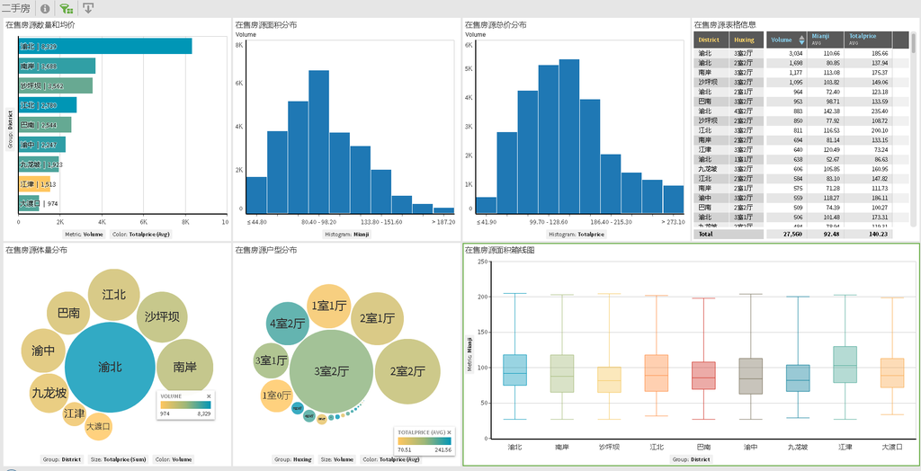

总价<300万,面积<200平

- 渝北的二手房数量(8000+)和房屋体量（总价）远高于其它地区。这跟渝北地多，经济向北发展有关系。
- 江津的二手房面积最大也最便宜，毕竟离主城远啊；沙坪坝的二手房小户型居多，估计相当一部分是学区房，只求有个入学名额，面积大小无所谓。
- 户型上看3室2厅是供应量最多的，但单价最贵的却是4室2厅大户型。改善性住房需求突出，供需关系决定了价格。
- 面积（应该是建筑面积)上看80-100平的最多，总价在110-150万的占较多。

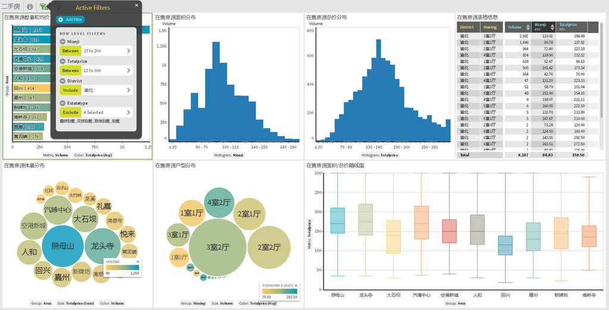

渝北住宅

### 5 主题分析

结合租房数据分析**租售比** （租售比=年租金/房价，反映房屋通过租金方式的回报率。房产的回报还可能是价值上涨）

> 从数据来看，美国的达拉斯、洛杉矶、纽约，日本的大阪、东京都有不错的表现，租金回报率达到5%以上。相比之下，中国一线城市北上广深的租金回报率就比较低了，仅1.5%左右。一般来说，城市越大租金回报率越低。  
> 参考 [全球热门城市房产出租回报排名出炉！](http://www.igo180.com/m/mnews/5012.html)

```r
#售租比中位数781，表示781个月，65年的房租收回房价（不计房屋维护费用税费等）
summary(df_zsb2$szb)
```

```
##    Min. 1st Qu.  Median    Mean 3rd Qu.    Max.
##   182.0   546.0   781.0   805.7  1029.5  1905.0
```

```r
#租售比四分位数
summary(df_zsb2$zsb)
```

```
##    Min. 1st Qu.  Median    Mean 3rd Qu.    Max.
##   0.630   1.166   1.537   1.852   2.198   6.602
```

数据中看出重庆主城房产的租售比中位数为**1.537%** （好低，跟报道上说的3.5%出入很大啊 [via](http://www.sohu.com/a/192014910_611257), 有可能是链家上的挂牌售价数据都有虚高成分，实际成交价可能要打个9折)。 因为此次只分析重庆房产，不跟其它城市作比较，所以各区各小区只比较数据，不用太在意绝对数值。

小区户型租售比(zsb)较高的多是比较成熟豪华装修的大户型，房价高但租金更高。

| district | area | xiaoqu | huxing | cnt | fangjia | fangzu | szb | zsb |
| --- | --- | --- | --- | --- | --- | --- | --- | --- |
| 江北 | 石马河 | 金科十年城洋房 | 4室2厅 | 5 | 3310000 | 16000 | 207 | 5.800604 |
| 渝北 | 石子山 | 龙湖源著北区 | 4室2厅 | 17 | 3603529 | 17000 | 212 | 5.661117 |
| 渝中 | 化龙桥 | 雍江艺庭 | 4室2厅 | 2 | 4275000 | 15000 | 285 | 4.210526 |
| 南岸 | 南滨路 | 和记黄埔珊瑚水岸一期 | 5室2厅 | 2 | 6000000 | 21000 | 286 | 4.200000 |
| 渝北 | 鸿恩寺 | 保利山庄别墅 | 5室2厅 | 9 | 8744444 | 30000 | 291 | 4.116900 |
| 渝北 | 人和 | 重庆棕榈泉国际中心 | 3室2厅 | 4 | 4012500 | 13667 | 294 | 4.087327 |

那些租售比最低的，则是租金便宜（因为配套成熟度没跟上），房价却不便宜（房价已在高位，上涨空间很少）。

| district | area | xiaoqu | huxing | cnt | fangjia | fangzu | szb | zsb |
| --- | --- | --- | --- | --- | --- | --- | --- | --- |
| 南岸 | 南滨路 | 长嘉汇 | 4室2厅 | 5 | 5000000 | 1500 | 3333 | 0.3600000 |
| 渝北 | 空港新城 | 鲁能城中央公馆二期 | 3室2厅 | 2 | 3280000 | 1300 | 2523 | 0.4756098 |
| 渝北 | 悦来 | 国博城 | 4室2厅 | 9 | 4294444 | 2000 | 2147 | 0.5588616 |
| 渝北 | 照母山 | 和记黄埔玥湖园 | 4室2厅 | 8 | 3500000 | 1750 | 2000 | 0.6000000 |
| 渝北 | 龙头寺 | 华宇天宫花城B组团 | 3室2厅 | 2 | 3350000 | 1800 | 1861 | 0.6447761 |
| 渝北 | 大石坝 | 华润中央公园 | 4室2厅 | 4 | 3320000 | 2100 | 1581 | 0.7590361 |

### 6 总结

按小王的期望和经济承担能力来看，在最火热的渝北买改善性住房也不是问题。相比于百里挑一，要是把眼光投向南岸，可选择的就更多了。 但刚需买房这个事，不只是看性价比啊，小王要是一心只要渝北，蔡家空港还不去，那就再多花点时间，找中介谈谈，实地考察 （交通，配套成熟度，学校等情况）。  
时间有限，数据有限。 小王又没给我钱，我就不负责任的到此为止了。  
感兴趣的可以在电脑上查看：http://t.cn/RsFj3aX

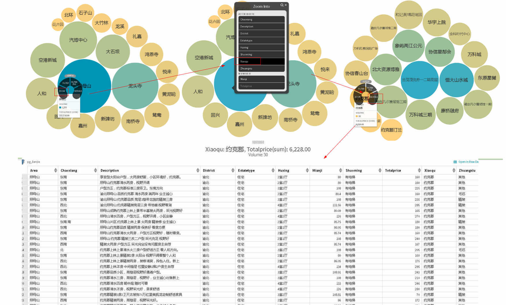